# exoplanet_detection

## Detecting and characterising an exoplanet using data from a light-curve

The aim of this project is to detect an exoplanet using the data from a light-curve (a series of brightness measurements taken at specific times) of the star WASP-5.

The code for reading and extracting data from the file:

```python
import numpy as np
import matplotlib.pyplot as plt

data = np.loadtxt("wasp-5b.txt", dtype=float)
t = data[:, 0]
flux = data[:, 1]
flux_error = data[:, 2]
```

Scatterplot to see the data

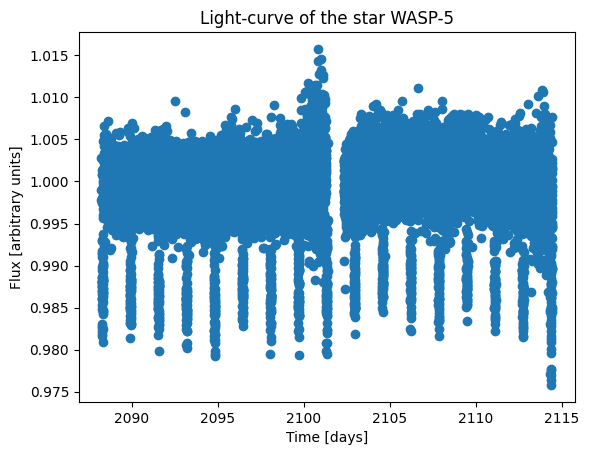

```python
plt.scatter(t, flux)
plt.title("Light-curve of the star WASP-5")
plt.xlabel("Time [days]")
plt.ylabel("Flux [arbitrary units]")
plt.show()
```

We see that the star has a periodic dip in brightness, indicating the possibility of an exoplanet (which has been detected and called WASP-5b) orbiting this star. To test this out, we implement the Box-Least-Squares (BLS) algorithm to first find the period of WASP-5b. The algorithm consists of a phase folding and a binning phase.

Below is the code that calculates these 2 statistics and returns the trial periods, $\Delta \chi ^{2}$, $\delta$ and the epoch, $t_0$ (defined as the mid-time of the transit signature).

```python
#statistics for each data point
weight=1/np.square(flux_error)
f_hat = np.sum(flux*weight)/np.sum(weight)
f_tilde = flux-np.full(np.shape(flux), f_hat)
T=sum(weight)

def bls(trial_period):
        phi_i = np.mod(t-t[0], trial_period) + t[0]

        #binning phase
        #create bins
        expected_duration = 2/24
        bin_edges = np.arange(min(phi_i), max(phi_i), expected_duration)
        distance_from_centre = np.append(np.diff(bin_edges) / 2, (np.diff(bin_edges) / 2)[0])
        bin_centres = distance_from_centre + bin_edges
        bin_indices=np.digitize(phi_i, bin_edges)

        #calculate the statistics for data points that fall in each bin
        S_j=[]
        R_j=[]

        for j in range(1, len(bin_edges)+1):
            f_i=[]
            w_i=[]
            index = np.where(bin_indices==j)[0]

            for i in index:
                f_i.append(f_tilde[i])
                w_i.append(weight[i])
            f_i=np.array(f_i)
            w_i=np.array(w_i)

            S_j.append(np.sum(f_i*w_i))
            R_j.append(np.sum(w_i))

        return np.array(S_j), np.array(R_j), np.array(bin_centres), np.array(phi_i)

def algorithm():
    """function that returns 4 arrays. The trial period, the maximum values of chi_{j}^2 for each trial period, and the depth and epoch associated with each chi """
    P=np.arange(1, 10, 0.01)
    max_chi = []
    max_delta = []
    max_t_0 = []
    for i in P:
        denominator = (bls(i)[1] * (T - bls(i)[1]))
        delta_j = bls(i)[0] * T / denominator
        chi_j = np.square(bls(i)[0]) * T / denominator

        index_max_chi = np.where(chi_j == max(chi_j))[0][0]

        max_t_0.append(bls(i)[2][index_max_chi])
        max_chi.append(chi_j[index_max_chi])
        max_delta.append(delta_j[index_max_chi])

    return P, max_chi, max_delta, max_t_0

P, max_chis, delta, t0 = algorithm()
```

We now have a value of $\Delta \chi ^{2}$ for each trial period. Below is a plot of the values of $\Delta \chi ^{2}$ for each trial period P.

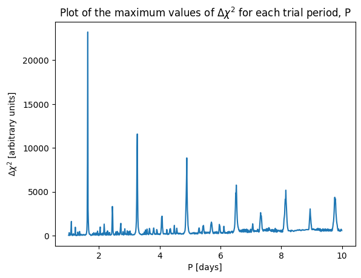

```python
plt.plot(P, max_chis)
plt.title(r"Plot of the maximum values of $\Delta \chi ^{2}$ for each trial period, P")
plt.xlabel("P [days]")
plt.ylabel(r"$\Delta \chi ^{2}$ [arbitrary units]")
plt.show()
```

We see a clear maximum value of $\Delta \chi ^{2}$, so we store it along the value for the period and its associated values of $\delta$ and $t_0$.

```python
index_max_chi = np.where(max_chis == max(max_chis))[0][0]
best_period = P[index_max_chi]
associated_delta = delta[index_max_chi]
associated_t0 = t0[index_max_chi]
phase = bls(best_period)[3]
```

We now have a best-fit trial period. We will phase fold the flux with this period to see how it looks like.

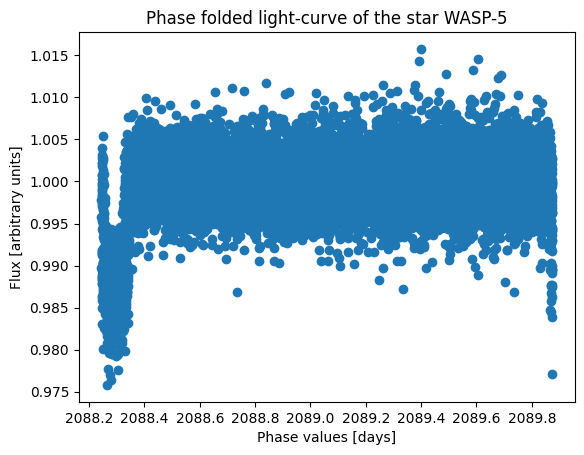

```python
plt.scatter(phase, flux)
plt.title("Phase folded light-curve of the star WASP-5")
plt.xlabel("Phase values [days]")
plt.ylabel("Flux [arbitrary units]")
plt.show()
```

As we can see, the dip doesn't line up perfectly every time it folds, as this is not the real period of the exoplanet, since we only searched discrete values of the period.

However, the calculated values will be good enough for a first approximation.

To find a better period, we make a basic model of the flux of the star, and fit this model to the actual data. This model flux will depend on some parameters like the radius of the exoplanet and its orbital radius, allowing us to then calculate the actual values.

```python
def F(p, z):
    def l(p, z):
        if 1 + p < z:
            return 0

        elif abs(1-p) < z <= 1+p:
            kappa_0 = np.acos(((p**2 + z**2 - 1) / (2 * p * z)))
            kappa_1 = np.acos(((1 - p**2 + z**2) / (2 * z)))
            sqrt = np.sqrt((4*z**2 - (1 + z**2 - p**2)**2) / 4)
            return (1/np.pi) * (p**2 * kappa_0 + kappa_1 - sqrt)

        elif z <= 1-p:
            return p**2

        elif z<=p-1:
            return 1

    return 1 - l(p, z)


def model_lightcurve(time_stamps, orbital_period, epoch, orbital_separation, size_ratio):
    theta_i = 2*np.pi*(time_stamps - epoch) / orbital_period
    z = abs(orbital_separation * np.sin(theta_i))

    f=[]
    for i in z:
        f.append(F(size_ratio, i))


    ind = np.where(np.cos(theta_i)<0)[0]
    for i in ind:
        f[i]=1

    return f

a_0 = 5
p = np.sqrt(abs(associated_delta))

#fit the model curve to the light curve
from scipy.optimize import curve_fit
params, _ = curve_fit(model_lightcurve, t, flux, p0=(best_period, associated_t0, a_0, p))

#refined parameters
refined_period, refined_t0, refined_a0, refined_p = params
refined_phase = bls(refined_period)[3]

#model flux with refined parameters
f = model_lightcurve(refined_phase, refined_period, refined_t0, refined_a0, refined_p)
```

The model flux will then look like this compared to the real flux.

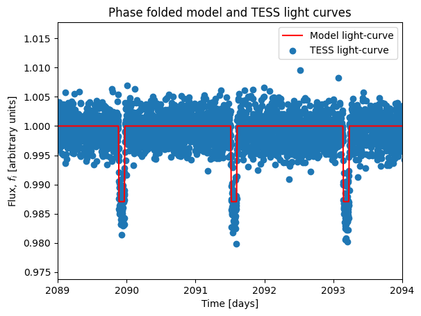

```python
plt.title("Phase folded model and TESS light curves")
plt.plot(t, f, color="r", label="Model light-curve")
plt.scatter(t, flux, label="TESS light-curve")
plt.xlabel("Time [days]")
plt.ylabel("Flux, $f_{i}$ [arbitrary units]")
plt.xlim(2089, 2094)
plt.legend()
plt.show()
```

Now, let's try to make the same phase folding as before, but with the new and improved best-fit period.

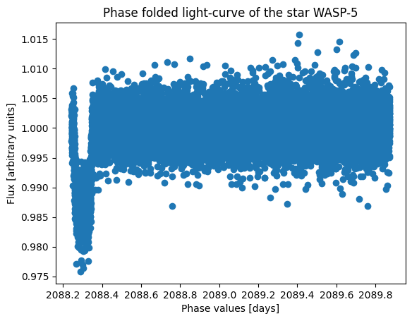

```python
plt.scatter(refined_phase, flux)
plt.title("Phase folded light-curve of the star WASP-5")
plt.xlabel("Phase values [days]")
plt.ylabel("Flux [arbitrary units]")
plt.show()
```

As we can see, this is a much better trial period, since the dip in brightness lines up perfectly everytime.

Finally, by knowing some proportions about this system and our Solar System, we can calculate the radius and the radius of the orbit of the exoplanet.

```python
R_jup = 1
R_sun = R_jup / 0.102763
R_star = 1.08 * R_sun
R_p = refined_p * R_star

R_sun_AU = 1/215.032
R_star_AU = 1.08 * R_sun_AU
d = refined_a0 * R_star_AU

print(f"Refined best-fit period: {refined_period} days")
print(f"Radius of WASP-5b: {R_p} R_jup")
print(f"Radius of the orbit of WASP-5b: {d} AU")
```

```
Refined best-fit period: 1.6284328126894285 days
Radius of WASP-5b: 1.1959622145259516 R_jup
Radius of the orbit of WASP-5b: 0.030668877008370343 AU
```